# Ilustracija istraživanja baze Expenditure and Default Data

Ines Pavlović, 052/2021

2024-08-22

## Uvodni deo

Cilj ovog rada je ispitivanje baze podataka Expenditure and Default Data, koja sadrži različite podatke o rashodima i nepoštovanju obaveza prema banci od strane ispitanika - korisnika banke koji su podneli zahtev za odobravanje kreditne kartice. Ova baza podataka preuzeta je sa sajta Rdatasets (Greene, W.H., 2003) i sastoji se od cross-section podataka o istoriji kreditnih kartica ispitanika.

Cross-section u ekonomiji i statistici odnosi se na vrstu podataka koji se prikupljaju u jednom određenom trenutku ili periodu za različite subjekte, kao što su pojedinci, domaćinstva, kompanije ili zemlje. Ovi podaci pružaju izgled informacija o različitim karakteristikama subjekata u istom vremenskom okviru, ali ne prate dalje njihove promene tokom vremena. To omogućava analizu trenutnog stanja i upoređivanje karakteristika među subjektima bez uvida u njihov vremenski razvoj.

U ovom radu, osim drugih istraživanja, posebna pažnja posvećena je analizi verovatnoće odobravanja zahteva za kreditnu karticu na osnovu ranije kreditne istorije pojedinca, kao i medjusobnih veza izmedju numeričkih i kategoričkih obeležja. Takođe, istraživanje je obuhvatilo i identifikaciju ključnih faktora koji utiču na finansijsko ponašanje korisnika kreditnih kartica.

#### Opis baze

Baza se sastoji od 1319 redova, kao i 12 kolona. Sastoji se iz 3 kategorička i 9 numeričkih obeležja, ovde je predstavljeno privh nekoliko redova:

```r
podaci = read.csv("CreditCard.csv")
head(podaci, 15)
```

```
##    rownames card reports      age income        share expenditure owner selfemp
## 1         1  yes       0 37.66667 4.5200 0.0332699100  124.983300   yes      no
## 2         2  yes       0 33.25000 2.4200 0.0052169420    9.854167    no      no
## 3         3  yes       0 33.66667 4.5000 0.0041555560   15.000000   yes      no
## 4         4  yes       0 30.50000 2.5400 0.0652137800  137.869200    no      no
## 5         5  yes       0 32.16667 9.7867 0.0670505900  546.503300   yes      no
## 6         6  yes       0 23.25000 2.5000 0.0444384000   91.996670    no      no
## 7         7  yes       0 27.91667 3.9600 0.0125757600   40.833330    no      no
## 8         8  yes       0 29.16667 2.3700 0.0764337600  150.790000   yes      no
## 9         9  yes       0 37.00000 3.8000 0.2456279000  777.821700   yes      no
## 10       10  yes       0 28.41667 3.2000 0.0197800000   52.580000    no      no
## 11       11  yes       0 30.50000 3.9500 0.0780245600  256.664200   yes      no
## 12       12   no       0 42.00000 1.9800 0.0006060606    0.000000   yes      no
## 13       13   no       0 30.00000 1.7300 0.0006936416    0.000000   yes      no
## 14       14  yes       0 28.83333 2.4500 0.0387955100   78.874170   yes      no
```

[output cut: 17 more lines]

Obeležje **card** označava da li je korisniku odobren ili odbijen zahtev za karticom.(binarno/kategoričko obeležje)

Obeležje **reports** označava broj većih nepovoljnih izveštaja o kreditnoj istoriji. **Income** je godišnji prihod korisnika, izražen u desetinama hiljada dolara.

Obeležje **age** predstavlja godine, koje su u deceimalnom obliku jer je 1 mesec, predstavljen kao 1/12 godine - dakle da neko ima 35 godina i 6 meseci, on bi u tabeli imao 35.5 godina. **Expenditure** je prosečna mesečna potrošnja putem kartice, u američkim dolarima. **Share** je odnos mesečne potrošnje putem kartice, u odnosu na godišnji prihod. Navedenih pet obeležja su numerička.

**Owner** označava da li korisnik poseduje svoju nekretninu, a **selfemp** da li je samozaposlen(binarno/kategoričko), dok je **dependents** broj ljudi koje korisnik izdržava(na primer deca roditelja…), **months** broj meseci tokom kojih osoba živi na datoj adresi.**Majorcards** je broj najvažnijih(najvećih) kreditnih računa koje pojedinac poseduje, dok je **active** broj aktivnih kreditnih računa.

## Kategorička i numerička obeležja

#### Kategorička obeležja

Za početak, posmatrana su binarna/kategorička obeležja.

###### Card

Posmatramo broj odbijenih i prihvaćenih zahteva, faktor su da i ne vrednosti.

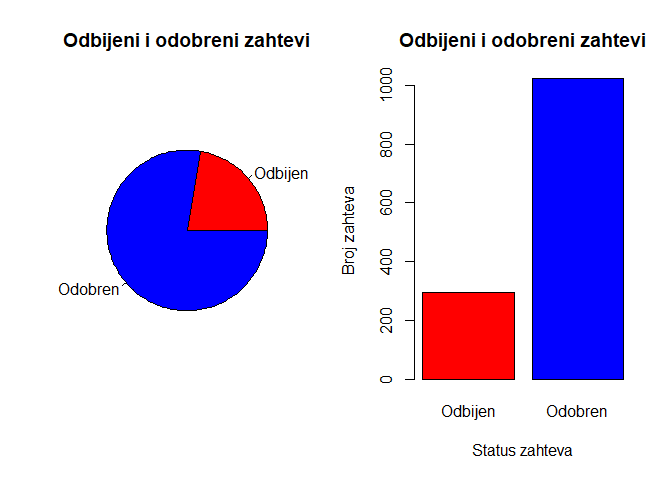

```r
par(mfrow = c(1,2))
pie(table(podaci$card),
    main = "Odbijeni i odobreni zahtevi",
    col = c("red", "blue"),
    labels = c("Odbijen", "Odobren"))
barplot(table(podaci$card),
    main = "Odbijeni i odobreni zahtevi",
    xlab = "Status zahteva",
    ylab = "Broj zahteva",
    col = c("red", "blue"),
    names.arg = c("Odbijen", "Odobren"))
```

Na grafiku, primećuje se da je znatno veći broj ljudi kojima je zahtev za karticom odobren (čak preko 1000), dok je broj odbijenih zahteva oko 300, dakle nešto manje od četvrtine zahteva je odbijeno (jer je poznato da je broj redova preko 1300). Ispod je navedenih i tačan broj odbijenih i odobrenih, izraženo i u procentima. Može se zaključiti da se kartica odobrava u 77% slučajeva.

```r
broj_kategorija <- table(podaci$card)

print(broj_kategorija)
```

```
##
##   no  yes
##  296 1023
```

```r
procenat = (broj_kategorija / sum(broj_kategorija)) * 100
print(procenat)
```

```
##
##       no      yes
## 22.44124 77.55876
```

###### Owner

Posmatra se broj ljudi koji poseduju nekretninu, faktor su da i ne vrednosti.

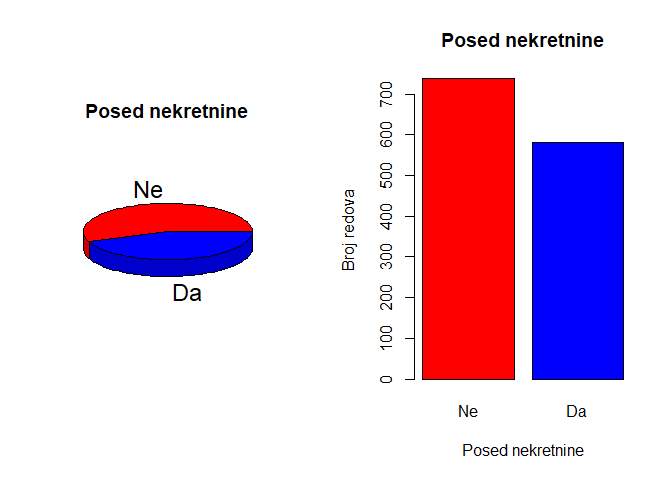

```r
par(mfrow = c(1,2))
library(plotrix)
pie3D(table(podaci$owner),
    main = "Posed nekretnine",
    col = c("red", "blue"),
    labels = c("Ne", "Da"))
barplot(table(podaci$owner),
    main = "Posed nekretnine",
    xlab = "Posed nekretnine",
    ylab = "Broj redova",
    col = c("red", "blue"),
    names.arg = c("Ne", "Da"))
```

Broj osoba koji poseduju nekretninu mnogo je ujednačeniji u odnosu na broj odbijenih i prihvaćenih zahteva. Vidimo da je broj ljudi koji ne poseduju nekretninu nešto veći od broja ljudi koji je poseduju(oko 55%). Za naše istraživanje, ovo je dobra raspodeljenost parametra (pošto će fokus istraživanja biti uticaj različitih vrednosti na odobravanje zahteva).

```r
broj_kategorija <- table(podaci$owner)

print(broj_kategorija)
```

```
##
##  no yes
## 738 581
```

```r
procenat = (broj_kategorija / sum(broj_kategorija)) * 100
print(procenat)
```

```
##
##       no      yes
## 55.95148 44.04852
```

###### Selfemp

Posmatra se broj osoba koji je samozaposlen u odnosu na broj osoba koje rade za nekoga

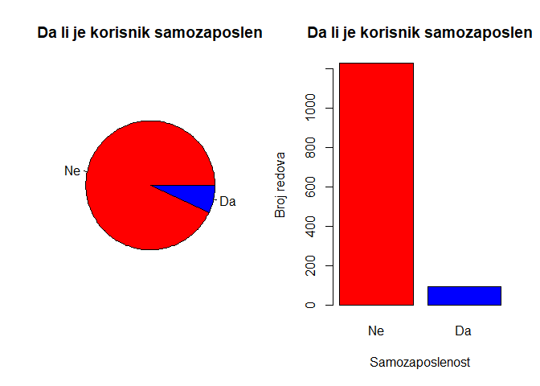

```r
par(mfrow = c(1,2))
pie(table(podaci$selfemp),
    main = "Da li je korisnik samozaposlen",
    col = c("red", "blue"),
    labels = c("Ne", "Da"))
barplot(table(podaci$selfemp),
    main = "Da li je korisnik samozaposlen",
    xlab = "Samozaposlenost",
    ylab = "Broj redova",
    col = c("red", "blue"),
    names.arg = c("Ne", "Da"))
```

Problem sa ovim obeležjem je što nije poznato da li su svi ljudi zaposleni (dakle, ako je neko nezaposlen, u koju kategoriju takav korisnik spada). Pretpostavićemo da su svi ljudi zaposleni, ako su im godišnji prihodi različiti od 0. Pogledajmo dalje da li postoje takvi korisnici, posmatramo minimum od income.

```r
interval = 1
interval <- range(podaci$income)
print(interval)
```

```
## [1]  0.21 13.50
```

Kako ne postoji korisnik čiji je prihod 0, uzima se kao pretpostavka da nema nezaposlenih korisnika.

```r
broj_kategorija <- table(podaci$selfemp)

print(broj_kategorija)
```

```
##
##   no  yes
## 1228   91
```

```r
procenat = (broj_kategorija / sum(broj_kategorija)) * 100
print(procenat)
```

```
##
##        no       yes
## 93.100834  6.899166
```

Primećuje se da je mnogo manji broj samozaposlenih, samo 91 od 1319 osoba, 7% od datog uzorka

#### Faktorisanje drugih vrednosti

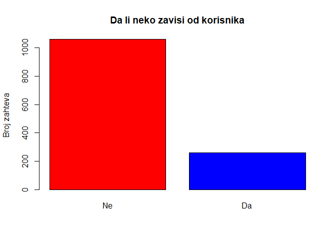

```r
ima_zavisnih<- ifelse(podaci$reports > 0, 1, 0)
barplot(table(ima_zavisnih),
    main = "Da li neko zavisi od korisnika",
    ylab = "Broj zahteva",
    col = c("red", "blue"),
    names.arg = c("Ne", "Da"))
```

Od koristi bi bilo još faktorisitati i jedno numeričko obeležje, broj većih negativnih izveštaja korisnika (obeležje reports). Dakle, moguće je podeliti korisnike na one koji su imali veće prestupe, i one koji nisu imali veće prestupe:

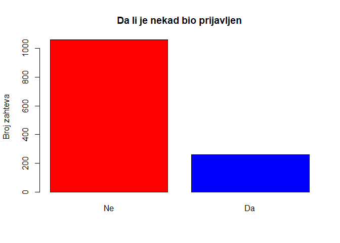

```r
prijavw <- ifelse(podaci$reports > 0, 1, 0)
barplot(table(prijavw),
    main = "Da li je nekad bio prijavljen",
    ylab = "Broj zahteva",
    col = c("red", "blue"),
    names.arg = c("Ne", "Da"))
```

###### Testiranje zavisnosti

Posmatrajmo zavisnost vrednosti card i vrednosti owner, a zatim vrednosti card i vrednosti selfemployed. Zavisnost posmatramo kako bi ustanovili koliko uticaj na odobrenje ima posed nekretnine (jer ona može predstavljati sigrnost banci za povrat novca u slučaju dugovanja, kao i da li je veća sigurnost za dobitak kartice ako korisnik nije samozaposlen). Koristiti će se chi kvadrat test. Pretpostavka će biti odbačena ako nam je p vrednost manja od 0.05, dakle sigurnost treba da bude veća od 95%.

Prvo, testiramo vrednosti card i owner:

```r
card_and_owner = table(podaci$card, podaci$owner)
card_and_owner
```

```
##
##        no yes
##   no  206  90
##   yes 532 491
```

Zanimljivo je primetiti da samo 90 osoba koje imaju nekretninu, imaju odbijen zahtev. Sprovdimo sad Hi kvadrat test, sa sledećim hipotezama:

H0: Nezavisne su

H1: Zavisne su

```r
chisq.test(podaci$card, podaci$owner)
```

```
##
##  Pearson's Chi-squared test with Yates' continuity correction
##
## data:  podaci$card and podaci$owner
## X-squared = 28.114, df = 1, p-value = 1.144e-07
```

Šta su dobijene vrednosti? X-squared predstavlja parametar hi kvadrat statistike, df je stepen slobode, dok je p vrednost verovatnoća da su ovakve vrednosti nastale nasumično. U hi kvadrat testovima, za procenu sigurnosti uglavnom se uzima da je p vrednost manja od 0.05.

Dakle, odbacuje se hipoteza H0, i dolazimo do zaključka da su ove dve vrednosti zavisne.

U sledećoj tabeli prikazana je zavisnost card i selfemp.

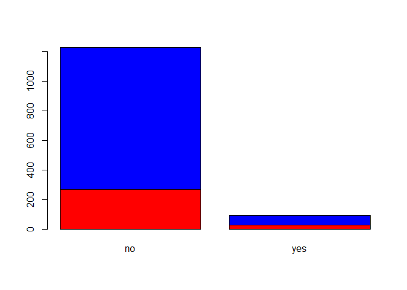

```r
zavisnost = table(podaci$card, podaci$selfemp)
barplot(zavisnost, col = c("red", "blue"))
```

Vidimo da su odnosi broja korisnika koji su samozaposlen ujednačeni u obe kolone(slicnih proporcija). Posmatajmo ponovo test, samo za paramtre selfemp i card. H0 biće da su obelezja nezavisna, a H1 da su zavisna.

```r
ima_zavisnih<- ifelse(podaci$reports > 0, 1, 0)
chisq.test(podaci$selfemp, podaci$card)
```

```
##
##  Pearson's Chi-squared test with Yates' continuity correction
##
## data:  podaci$selfemp and podaci$card
## X-squared = 3.3979, df = 1, p-value = 0.06528
```

Kako je ovde p vrednost 0.06(veće od 0.05), ne odbacujemo hipotezu. Iako p vrednost jeste mala, nije manja od 0.05 tako da ne možemo odbaciti našu hipotezu, ove vrednosti su nezavisne.

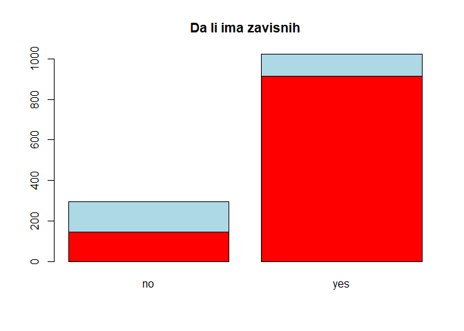

```r
barplot((table(ima_zavisnih, podaci$card)), main = "Da li ima zavisnih", col = c("red", "lightblue"))
```

Testirajmo sada hi kvadrat testom zavisnost ovih paramtera

```r
ima_zavisnih<- ifelse(podaci$reports > 0, 1, 0)
chisq.test(ima_zavisnih, podaci$card)
```

```
##
##  Pearson's Chi-squared test with Yates' continuity correction
##
## data:  ima_zavisnih and podaci$card
## X-squared = 235.55, df = 1, p-value < 2.2e-16
```

Nulta hipoteza bila je da su ove vrednosti nezavisne. Medjutim, kako je p vrednost manja od 0.05, hipoteza se odbija i zaključujemo da su obeležja card i reports zavisna.

Posmatra se, sada kolona reports u odnosu na kolonu card.

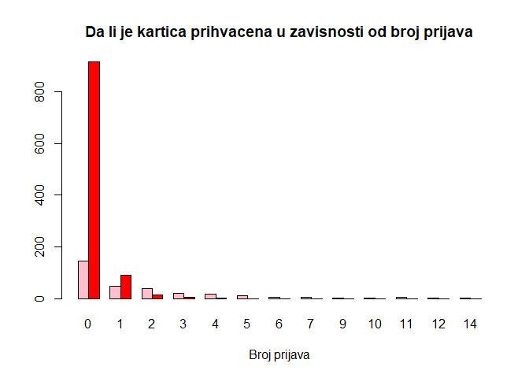

```r
barplot(t(table(podaci$report, podaci$card)), beside = TRUE, main = "Da li je kartica prihvacena u zavisnosti od broj prijava", xlab = "Broj prijava", col = c("pink", "red"))
```

Ružičastom bojom prikazan je broj odbijenih, dok crvenom broj odobrenih kartica. Primećuje se da je broj odobrenih prijava znatno veći kod osoba koje imaju 0 ili 1 prijavu, dok nakon toga, u slučajevima gde osoba ima 2 ili više prijave, više je odbijenih nego prihvaćenih. Možemo testirati posmatrane vrednosti:

```r
chisq.test(podaci$card, podaci$reports)
```

```
##
##  Pearson's Chi-squared test
##
## data:  podaci$card and podaci$reports
## X-squared = 342.65, df = 12, p-value < 2.2e-16
```

Nulta hipoteza bila je da su ove vrednosti nezavisne. Medjutim, kako je p vrednost manja od 0.05, hipoteza se odbija i zaključujemo da su obeležja card i reports zavisna.

#### Numerička obeležja

Posmatrajmo obeležje income (neprekidno numeričko obelezje).

```r
mean(podaci$income)
```

```
## [1] 3.365376
```

```r
prosecna_mesecna = (podaci$income)/12
mean(prosecna_mesecna)
```

```
## [1] 0.280448
```

```r
median(podaci$income)
```

```
## [1] 2.9
```

```r
var (podaci$income)
```

```
## [1] 2.869303
```

```r
sd (podaci$income)
```

```
## [1] 1.693902
```

```r
hist(podaci$income, prob = TRUE, col = "lightblue", main="Histogram za prikaz godisnje zarade", xlab="Zarada", ylab ="Učestalost")
var(podaci$income)
```

```
## [1] 2.869303
```

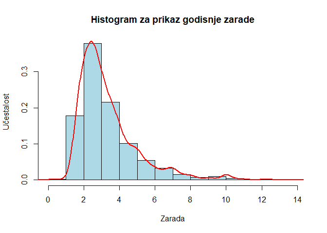

```r
lines(density(podaci$income), col = "red", lwd =2)
```

Pogledajmo i raspon ove promenljive, kao i kvantile i interkvartilno rastojanje:

```r
quantile(podaci$income)
```

```
##       0%      25%      50%      75%     100%
##  0.21000  2.24375  2.90000  4.00000 13.50000
```

```r
IQR(podaci$income)
```

```
## [1] 1.75625
```

```r
range(podaci$income)
```

```
## [1]  0.21 13.50
```

Primećujemo da je grafik asimetričan,jer je desni rep funkcije gustine raspodele znatno duži od desnog.

Sada se posmatraju obeležja expenditure, share i age, kao i njihove funkcije gustine raspodele

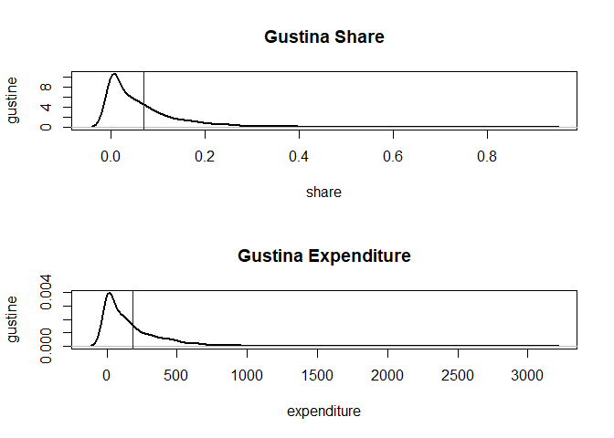

```r
par(mfrow = c(2,1))
library(plotrix)
plot (density(podaci$share), main = "Gustina Share", xlab = "share", ylab = "gustine", lwd = 2 )
abline(v = mean(podaci$share), col = "blue", lwd = 1.5)
plot (density(podaci$expenditure), main = "Gustina Expenditure", xlab = "expenditure", ylab = "gustine", lwd = 2 )
abline(v = mean(podaci$expenditure), col = "blue", lwd = 1.5)
```

Deluje da ova dva obeležja imaju sličnu raspodelu, pa možemo da uradimo KS test(Kolmogorov-Smirnovljev test) da bi ustanovili tačnost pretpostavke. Nulta hipoteza je da su oba obeležja iz iste distribucije

```r
ks.test(podaci$share, podaci$expenditure)
```

```
##
##  Asymptotic two-sample Kolmogorov-Smirnov test
##
## data:  podaci$share and podaci$expenditure
## D = 0.75891, p-value < 2.2e-16
## alternative hypothesis: two-sided
```

Ovo su rezultati našeg testa.

Kako je p vrednost manja od 0.05, odbacujemo H0 pretpostavku(da su ova obeležja iz iste raspodele).

Ispod su navedene ostale osnovne statistike za ova dva obeležja

```r
summary(podaci$expenditure)
```

```
##     Min.  1st Qu.   Median     Mean  3rd Qu.     Max.
##    0.000    4.583  101.298  185.057  249.036 3099.505
```

```r
summary(podaci$share)
```

```
##      Min.   1st Qu.    Median      Mean   3rd Qu.      Max.
## 0.0001091 0.0023159 0.0388272 0.0687322 0.0936168 0.9063205
```

Posmatramo sada obeležje age iz podataka.

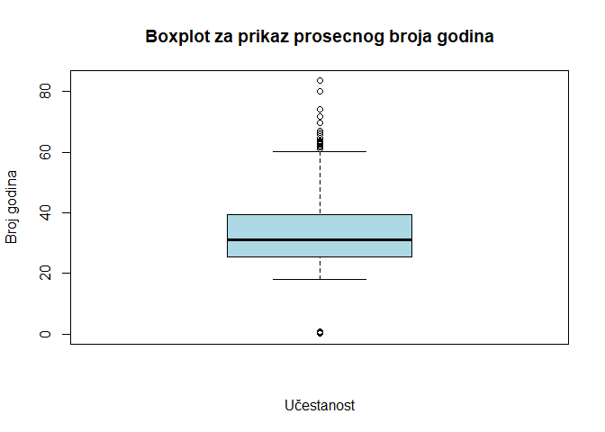

```r
boxplot(podaci$age, prob = TRUE, col = "lightblue", main="Boxplot za prikaz prosecnog broja godina", xlab="Učestanost", ylab ="Broj godina")
```

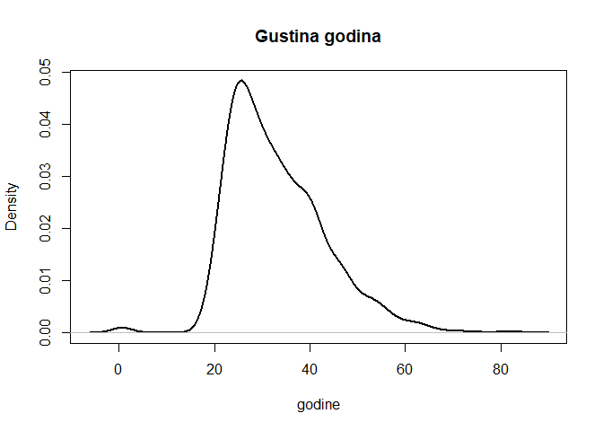

```r
plot (density(podaci$age), main = "Gustina godina", xlab = "godine", lwd = 2 )
```

Vidimo da postoji veći broj outlejera za broj godina veći od 60.

Iako ima outlajere i nije potpuno simetrična, gustina raspodele broja godina podseća na grafik normalne raspodele, pa je dobro uraditi KS test

```r
ks.test(podaci$age, pnorm(nrow(podaci),mean(podaci$age), var(podaci$age)))
```

```
##
##  Exact two-sample Kolmogorov-Smirnov test
##
## data:  podaci$age and pnorm(nrow(podaci), mean(podaci$age), var(podaci$age))
## D = 0.99469, p-value = 0.01212
## alternative hypothesis: two-sided
```

Posmatrajmo sada numeričko obeležje dependents

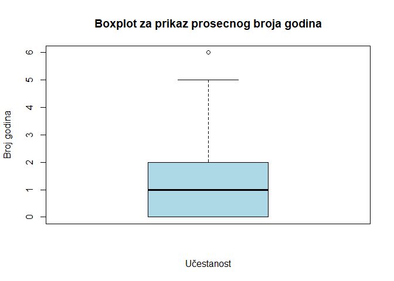

```r
boxplot(podaci$dependents, prob = TRUE, col = "lightblue", main="Boxplot za prikaz prosecnog broja godina", xlab="Učestanost", ylab ="Broj godina")
```

Primećujemo da se vrednosti ove varijable generalno kreću izmedju 0 i 2, sa ponekim izuetkom(nema značajnih razlikau podacima).

Moguće je izvršiti podelu prema više faktora. Znamo da je podela na posed nekretnine u odnosu 55:45.

```r
poseduju = subset(podaci, podaci$owner=="yes")
nemaju = subset(podaci, podaci$owner=="no")
```

```r
t.test(poseduju$age, nemaju$age, var.equal = TRUE)
```

```
##
##  Two Sample t-test
##
## data:  poseduju$age and nemaju$age
## t = 14.351, df = 1317, p-value < 2.2e-16
## alternative hypothesis: true difference in means is not equal to 0
## 95 percent confidence interval:
##  6.483913 8.537218
## sample estimates:
## mean of x mean of y
##  37.41538  29.90481
```

Kako je p-vrednost manja od 0.05, odbacujemo našu hipotezu i zakljucujmo da postoje znacajne razlike u srednjim vrednostima ovih podgrupa

```r
mean(nemaju$age)
```

```
## [1] 29.90481
```

```r
mean(poseduju$age)
```

```
## [1] 37.41538
```

## Spirmanov test korelisanosti

Kako za obeležje income ne možemo zaključiuti normalnu raspodelu, koristićemo Spirmanov test za korelisanost.

Spearmanov rang-korelacioni koeficijent meri snagu i pravac monotone veze između dve varijable. Ovaj koeficijent se koristi kada varijable nisu nužno normalno distribuirane ili kada su podaci ordinalni.

Nulta hipoteza (H0): Nema monotone veze između varijabli (Spearmanov koeficijent korelacije ρ = 0). Alternativna hipoteza (H1): Postoji monotona veza između varijabli (Spearmanov koeficijent korelacije ρ ≠ 0).

Spearmanov koeficijent korelacije se izračunava kao: р= 1-6 *(sum(di)/(n*(n^2-1).

Raspodela test statistike pri H0:

Kada je nulta hipoteza tačna, Spearmanov koeficijent korelacije prati raspodelu sličnu raspodeli t-distribucije sa n-2 stepeni slobode u malim uzorcima. U velikim uzorcima, raspodela je približno normalna. U r-u postoji ugradjena funkcija, koja implementira ovaj test, pa cemo je prvo pomocu nje implementirati test.

```r
cor.test(podaci$income, podaci$age, method = "spearman", exact = FALSE)
```

```
##
##  Spearman's rank correlation rho
##
## data:  podaci$income and podaci$age
## S = 230769616, p-value < 2.2e-16
## alternative hypothesis: true rho is not equal to 0
## sample estimates:
##       rho
## 0.3966133
```

.Kako je p vrednost veoma mala, možemo odbaciti nultu hipotezu i zaključiti da su ova obeležja zavisna, treba još implementirati ovaj test ručno:

```r
rank1 = rank(podaci$age)
rank2 = rank(podaci$income)


D = rank1-rank2
Dkvadrat = D^2

n  = nrow(podaci)
rho = 1 - (6 * sum(Dkvadrat)) / (n * (n^2 - 1))


t_statistic <- rho * sqrt(n - 2) / sqrt(1 - rho^2)


p =  2 * pt(-abs(t_statistic), df = n - 2)

print(p)
```

```
## [1] 5.887767e-51
```

Koristili smo t statistiku, sa n-2 stepena slobode. Mi smo dobili još manju vrednost nego sa ugradjenim testom, tako da se u oba slučaja odbacuje H0 hipoteza da su ova obeležja, dakle postoji monotona veza izmedju obeležja.

## Zaključak

Rad bi mogao biti unapredjen ispitivanjem preostalih numeričkih obeležja, ispitivanjem povezanosti dependents i expendeture(koliko neko troši u odnosu na broj ljudi koji od njega zavisi), a zatim i posmatranjem tog odnosa i odobravanja/odbijanja kartice. Mogla bi se testirati i povezanost izmedju majorcards i active(broja većih i aktivnih računa), kao i broja aktivnih kreditnih računa i obeležja(card).

Ines Pavlović